# Fundamentos de Probabilidade para Decisões - Parte 2

Características da Distribuição de Probabilidade de Variáveis Aleatórias

Autor

Mateus Rezende Bispo

Data de Publicação

28 de maio de 2025

# 1 Características da Distribuição de Probabilidade de Variáveis Aleatórias

## 1.1 Características Sumarizam Informação

Uma distribuição de probabilidade contém **infinitos** pontos de informação. Na prática, é impossível analisar cada valor possível de uma VA e suas respectivas probabilidades.

Por isso, precisamos de **medidas-resumo** que capturem as características essenciais da distribuição em poucos números interpretáveis.

**1. Posição: Onde os Dados se Concentram?**

- **Valor Esperado**: Resume em um único número o “centro” da distribuição
- Transforma infinitas possibilidades em uma métrica gerenciável

**2. Variabilidade: Quantificando a Incerteza**

- **Variância e Desvio-Padrão**: Condensam toda a dispersão dos dados em uma medida
- Permitem comparar riscos entre diferentes investimentos ou processos
- Essenciais porque dois processos podem ter mesma média mas riscos totalmente diferentes

**3. Forma da Distribuição: Capturando Padrões Não-Simétricos**

- **Assimetria e Curtose**: Resumem desvios do padrão normal
- Identificam se eventos extremos são mais prováveis que o esperado
- Críticos porque muitos fenômenos empresariais não seguem o padrão “normal”

**4. Interdependências: Síntese de Relações Complexas**

- **Covariância e Correlação**: Reduzem relações multidimensionais a números interpretáveis
- Permitem decisões de diversificação sem analisar cada cenário possível

## 1.2 Variância

A variância $V(X)$ de uma variável aleatória $X$ mede a dispersão dos valores de $X$ em torno do seu valor esperado.

Para uma VA Discreta:

$$V(X) = \sigma_{X}^2 = \sum_{i} (x_i - E(X))^2 P(X = x_i)$$

Para uma VA Contínua:

$$V(X) = \sigma_{X}^2 = \int_{-\infty}^{\infty} (x - E(X))^2 f(x) \, dx$$

## 1.3 Desvio-Padrão

O desvio-padrão ($\sigma$) de uma VA é a raiz quadrada da variância e fornece uma medida da dispersão dos valores de $X$ em torno do seu valor esperado na mesma unidade de $X$.

$$\sigma = \sqrt{V(X)}$$

Por exemplo, se a unidade de $X$ for R$ (reais), o desvio-padrão também será em reais, enquanto a variância será em reais ao quadrado (R$$^2$).

## 1.4 Variância e Desvio-Padrão: Exemplo Prático

Implementação em R:

```r
# Definir os dados
lucros <- c(2000, 5000, 8000)
probabilidades <- c(0.3, 0.4, 0.3)
```

Calculando o valor esperado:

```r
valor_esperado <- sum(lucros * probabilidades)
valor_esperado
```

```
[1] 5000
```

Calculando a variância manualmente:

```r
variancia <- sum((lucros - valor_esperado)^2 * probabilidades)
variancia
```

```
[1] 5400000
```

Calculando o desvio-padrão

```r
desvio_padrao <- sqrt(variancia)
desvio_padrao
```

```
[1] 2323.79
```

Verificação usando simulação:

```r
# fixa a semente para reprodutibilidade
set.seed(123)

# Simulação de 10.000 amostras
simulacao <- sample(lucros, 10000, prob = probabilidades, replace = TRUE)
```

Valor esperado empírico:

```r
mean(simulacao)
```

```
[1] 5036.6
```

Variância empírica:

```r
var(simulacao)
```

```
[1] 5422602.7
```

Desvio-padrão empírico:

```r
sd(simulacao)
```

```
[1] 2328.6483
```

## 1.5 Propriedades da Variância

```r
# Exemplo das propriedades
set.seed(123)
investimento <- rnorm(1000, mean = 0.05, sd = 0.12)  # Retorno 5%, vol 12%
```

Propriedade 1: $V(X + constante) = V(X)$, adicionar uma constante não altera o risco

```r
taxa <- 0.02
var(investimento)
```

```
[1] 0.014161809
```

```r
var(investimento + taxa)
```

```
[1] 0.014161809
```

Propriedade 2: $V(a*X) = a^2V(X)$, dobrar o investimento quadruplica o risco

```r
dobro_investimento <- 2 * investimento
var(investimento)
```

```
[1] 0.014161809
```

```r
var(dobro_investimento)  # 4 vezes maior
```

```
[1] 0.056647234
```

```r
2^2 * var(investimento)  # Confirmação teórica
```

```
[1] 0.056647234
```

## 1.6 Coeficiente de Variação

O **coeficiente de variação (CV)** é uma medida de variabilidade relativa que expressa o desvio-padrão como uma porcentagem da média, permitindo comparações diretas entre variáveis com diferentes escalas ou unidades.

$$CV = \frac{\sigma}{|\mu|} \times 100\%$$

onde:

- $\sigma$ = desvio-padrão da variável aleatória
- $\mu$ = valor esperado (média) da variável aleatória

**Características principais:**

- **Adimensional**: Expresso em porcentagem, independe da unidade de medida
- **Comparável**: Permite comparar variabilidade entre variáveis diferentes
- **Interpretação**: Quanto maior o CV, maior a variabilidade relativa

**Interpretação prática:**

- A interpretação da magnitude do CV depende da processo aleatório em estudo, mas geralmente um CV mais alto indica maior variabilidade relativa.

## 1.7 Coeficiente de Variação: Exemplo Comparativo

Cálculo do CV para cada investimento

```r
# Ação Tech
retorno_acao <- 15
desvio_acao <- 6
cv_acao <- (desvio_acao / retorno_acao) * 100
cv_acao
```

```
[1] 40
```

```r
# Fundo Imobiliário
retorno_fundo <- 1200
desvio_fundo <- 180
cv_fundo <- (desvio_fundo / retorno_fundo) * 100
cv_fundo
```

```
[1] 15
```

```r
# Criptomoeda
retorno_crypto <- 50
desvio_crypto <- 25
cv_crypto <- (desvio_crypto / retorno_crypto) * 100
cv_crypto
```

```
[1] 50
```

## 1.8 Aplicação: Valor-em-Risco (VaR)

O **Valor-em-Risco (VaR)** é uma medida estatística que quantifica o risco de perdas em um investimento ou portfólio durante um período específico, com um determinado nível de confiança.

**Definição formal**: O VaR de α% é o valor tal que existe apenas α% de probabilidade de a perda exceder esse valor.

**Elementos do VaR**:

- **Horizonte temporal**: Período de análise (1 dia, 1 semana, 1 mês)
- **Nível de confiança**: Tipicamente 95% ou 99%
- **Unidade monetária**: Valor máximo de perda esperada

**Interpretação do VaR de 95%**:

“Existe apenas 5% de chance de a perda exceder o valor do VaR”

**Aplicações práticas**:

- Gestão de risco em bancos e fundos
- Determinação de limites de exposição
- Cálculo de capital regulatório
- Comunicação de risco para investidores

## 1.9 VaR usando a Distribuição Normal

Implementação do VaR usando a distribuição normal em R:

```r
# Parâmetros do investimento
retorno_medio <- 0.012      # 1.2% ao mês
volatilidade <- 0.045       # 4.5% ao mês
valor_investido <- 100000   # R$ 100.000
```

Cálculo do VaR 95%:

```r
nivel_confianca <- 0.95
quantil_95 <- qnorm(1 - nivel_confianca)  # -1.645
quantil_95
```

```
[1] -1.6448536
```

Cálculo do VaR 95% percentual:

```r
var_percentual_95 <- retorno_medio + quantil_95 * volatilidade
var_percentual_95
```

```
[1] -0.062018413
```

Cálculo do VaR 95% monetário:

```r
var_monetario_95 <- valor_investido * var_percentual_95
var_monetario_95
```

```
[1] -6201.8413
```

Cálculo do VaR 99%

```r
quantil_99 <- qnorm(1 - 0.99)  # -2.326
quantil_99
```

```
[1] -2.3263479
```

Cálculo do VaR 99% percentual:

```r
var_percentual_99 <- retorno_medio + quantil_99 * volatilidade
var_percentual_99
```

```
[1] -0.092685654
```

Cálculo do VaR 99% monetário:

```r
var_monetario_99 <- valor_investido * var_percentual_99
var_monetario_99
```

```
[1] -9268.5654
```

## 1.10 Exercício 1

**Cenário**: Um gestor de investimentos está comparando dois fundos com diferentes perfis de risco.

**Dados Calculados**:

- **Fundo Conservador**: Retorno esperado = 8.6%, Desvio-padrão = 1.9%
- **Fundo Arrojado**: Retorno esperado = 10.2%, Desvio-padrão = 6.9%

**Perguntas**:

1. Calcule o coeficiente de variação para cada fundo.
2. Compare o risco relativo dos dois fundos.
3. Qual fundo você recomendaria para um investidor conservador? Justifique.

## 1.11 Solução do Exercício 1

# 2 Cálculo dos Coeficientes de Variação (CV)

```r
cv_fundo_conservador <- (1.9 / 8.6) * 100
cv_fundo_conservador
```

```
[1] 22.093023
```

```r
cv_fundo_arrojado <- (6.9 / 10.2) * 100
cv_fundo_arrojado
```

```
[1] 67.647059
```

Interpretação:

- Apesar do fundo arrojado ter um retorno esperado maior, seu coeficiente de variação (CV) é significativamente maior, indicando que o risco relativo é muito mais alto, cerca de 3 vezes ($67/22 \approx 3$) maior que o risco do fundo conservador.

## 2.1 Exercício 2

**Cenário**: Uma loja está comparando a previsibilidade da demanda de dois produtos.

**Dados**:

- **Produto A**: Demanda Esperada = E(D) = $\mu$ = 100 unidades, $\sigma$ = 15 unidades
- **Produto B**: Demanda Esperada = E(D) = $\mu$ = 50 unidades, $\sigma$ = 12 unidades

**Perguntas**:

1. Calcule o coeficiente de variação para cada produto.
2. Qual produto tem maior risco relativo de demanda?
3. Qual seria mais desafiador para gerenciar estoque?

## 2.2 Solução do Exercício 2

Cálculo dos Coeficientes de Variação (CV):

```r
cv_a <- (15 / 100) * 100
cv_a
```

```
[1] 15
```

```r
cv_b <- (12 / 50) * 100
cv_b
```

```
[1] 24
```

Interpretação:

- Como o coeficiente de variação da demanda do produto b é maior que o do produto a, isso indica que o produto b tem uma maior variabilidade (risco) relativa do que a do produto a, assim, é mais desafiador gerenciar o estoque do produto b.

## 2.3 Exercício 3

Você está analisando um portfólio de títulos governamentais com:

- Retorno médio mensal: 0.8%
- Volatilidade mensal: 3.2%
- Valor investido: US$ 250.000

Considerando que os retornos do protfólio seguem aproximadamente uma distribuição normal:

- Calcule o VaR mensal de 95% (percentual e monetário)
- Calcule o VaR mensal de 99% (percentual e monetário)
- Compare os resultados e interprete a diferença

**Dica**: Use `qnorm()` no R para obter os quantis da distribuição normal

## 2.4 Solução do Exercício 3

```r
# Parâmetros do investimento
retorno_medio <- 0.008     # 0.8%
volatilidade <- 0.032      # 3.2%
valor <- 250000            # US$ 250k
```

VaR 95% percentual:

```r
var_95_percentual <- retorno_medio + qnorm(0.05) * volatilidade
var_95_percentual
```

```
[1] -0.044635316
```

VaR 95% monetário:

```r
var_95_monetário <- valor * var_95_percentual
var_95_monetário
```

```
[1] -11158.829
```

VaR 99% percentual:

```r
var_99_percentual <- retorno_medio + qnorm(0.01) * volatilidade
var_99_percentual
```

```
[1] -0.066443132
```

VaR 99% monetário:

```r
var_99_monetário <- valor * var_99_percentual
var_99_monetário
```

```
[1] -16610.783
```

# 3 Covariância e Dependência entre Variáveis Aleatórias

## 3.1 Covariância/Correlação: Exemplo

**Dados hipotéticos** de uma sorveteria durante 5 dias:

| Dia | Temperatura (°C) | Vendas (R$) |
| --- | --- | --- |
| 1 | 25 | 300 |
| 2 | 30 | 450 |
| 3 | 20 | 200 |
| 4 | 35 | 500 |
| 5 | 28 | 400 |

**Médias**:

- Temperatura média: 27.6°C
- Vendas médias: R$ 370

**Interpretação da Covariância/Correlação**:

- Se **positiva**: quando temperatura aumenta, vendas tendem a aumentar
- Se **negativa**: quando temperatura aumenta, vendas tendem a diminuir
- Se **zero**: não há relacionamento linear entre as variáveis

## 3.2 Exemplo: Gráfico de Dispersão

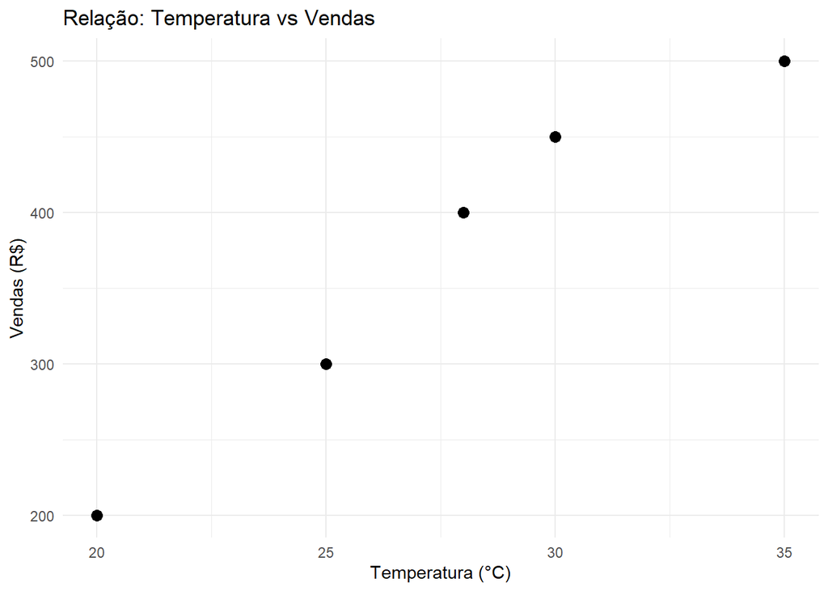

Interpretação do Gráfico:

- O gráfico de dispersão mostra uma relação positiva forte entre temperatura e vendas.
- indicando que, à medida que a temperatura aumenta, as vendas também tendem a aumentar, e vice-versa.

## 3.3 Implementação em R

```r
# Função cov para calcular a covariância
covariancia <- cov(temperatura, vendas)
covariancia
```

```
[1] 660
```

```r
# Função cor para calcular a correlação
correlacao <- cor(temperatura, vendas)
correlacao
```

```
[1] 0.97968795
```

- Como indicado pelo gráfico de dispersão, há uma correlação positiva muito forte entre temperatura e vendas de sorvete, (0.97 ou 97%).
- Se a temperatura aumenta, as vendas tendem a aumentar também, e vice-versa.

## 3.4 Exercício 1

**Cenário**: Um investidor está analisando a correlação entre os retornos de duas ações para construir um portfólio diversificado. Os retornos mensais históricos (em %) das duas ações nos últimos 6 meses foram:

| Mês | Ação A | Ação B |
| --- | --- | --- |
| 1 | 2.5 | 1.8 |
| 2 | -1.2 | 3.1 |
| 3 | 4.1 | -0.5 |
| 4 | 1.8 | 2.4 |
| 5 | -0.8 | 1.2 |
| 6 | 3.6 | -1.0 |

**Perguntas**:

1. Faça um gráfico de dispersão dos retornos das duas ações. Analisando o gráfico, você considera que há alguma correlação entre os retornos das duas ações? Se sim, qual?
2. Calcule a covariância e o coeficiente de correlação entre as duas ações.
3. Com base na correlação, essas ações são uma boa opção para diversificação? Explique.

## 3.5 Solução do Exercício 1

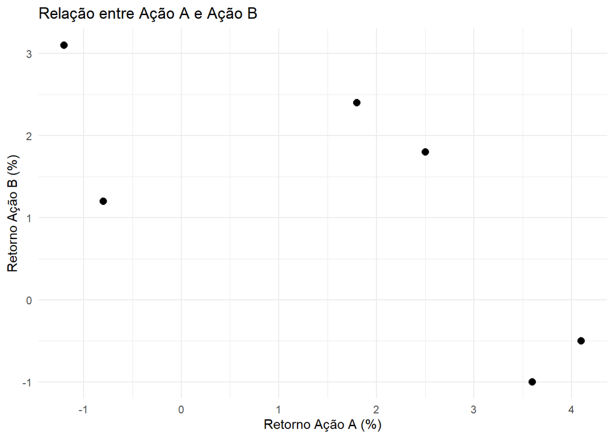

Interpretação:

- Analisando o gráfico de dispersão, parece haver uma correlação negativa forte entre os retornos das ações A e B, indicando que quando uma ação tem um retorno positivo, a outra tende a ter um retorno negativo, e vice-versa.

```r
# Cálculo da covariância
covariancia <- cov(acao_a, acao_b)
covariancia
```

```
[1] -2.6353333
```

```r
# Cálculo correlação
correlacao <- cor(acao_a, acao_b)
correlacao
```

```
[1] -0.73198834
```

# 4 Fundamentos de Simulação de Monte Carlo

## 4.1 Probabilidade e Simulação de MC

- Vejamos um exemplo inicial muito simples.
- Considere simular a probabilidade de que uma moeda honesta resulte “cara” em $n$ lançamentos. Pode-se fazer uma simulação física apenas jogando uma moeda várias vezes e tomando a proporção de caras para estimar $P(Caras)$.
- Usando um computador, escolha o número de tentativas n (quanto maior, melhor) e utilize o seguinte comando R:

```r
sample(0:1, n, replace = T)
```

- O comando faz uma amostragem com reposição de ${0, 1}$, $n$ vezes de forma que os resultados sejam igualmente prováveis.
- Considerando que $0$ representa coroa e 1 representa cara, a saída é uma sequência de $n$ uns e zeros correspondentes a caras e coroas.
- A média da sequência é precisamente a proporção de uns.

Para simular o lançamento de uma moeda justa (processo aleatório) e estimar a $P(Cara)$ fazemos:

```r
mean(sample(0:1, 100, replace = T))
```

```
[1] 0.46
```

```r
mean(sample(0:1, 1000, replace = T))
```

```
[1] 0.481
```

```r
mean(sample(0:1, 10000, replace = T))
```

```
[1] 0.4975
```

```r
mean(sample(0:1, 100000, replace = T))
```

```
[1] 0.49881
```

```r
mean(sample(0:1, 1000000, replace = T))
```

```
[1] 0.499707
```

## 4.2 Simulação de Monte Carlo - Aplicação em Finanças

**Procedimento Simplificado**:

- **Definição do Problema**: Identifique uma variável aleatória financeira de interesse (receitas, lucros, etc.) e os possíveis cenários que podem afetá-la.
- **Determinação das Probabilidades**: Atribua probabilidades a cada cenário com base em dados históricos ou estimativas.
- **Execução das Simulações**: Realize um grande número de simulações (por exemplo, 10.000) para gerar uma distribuição dos possíveis valores da variável aleatória de interesse
- **Análise dos Resultados**: Calcule estatísticas como a média (valor esperado), probabilidades e outras medidas de interesse.

## 4.3 Exemplo de Aplicação 1

Vamos considerar a mesma empresa que está planejando suas receitas para o próximo ano, mas desta vez, utilizaremos a simulação de Monte Carlo para modelar a incerteza nas receitas.

**Procedimento**:

1. Realizar 10.000 simulações.
2. Em cada simulação, selecionar um cenário com base nas probabilidades e registrar a receita correspondente.
3. Calcular a média das receitas simuladas (receita esperada).
4. Calcular a probabilidade da receita ser positiva.

## 4.4 Exemplo de Aplicação 1 - Implementação em R

```r
# define os cenários e as probabilidades
cenarios <- c(-500000, 1500000, 2000000)
probabilidades <- c(0.2, 0.5, 0.3)

# número de simulações
simulacoes <- 10000

# função para realizar selecionar um cenário e receita
simulacao_receita <- function() {
  sample(cenarios, size = 1, prob = probabilidades, replace = TRUE)
}

# executando as simulações
set.seed(123)
receitas_simuladas <- replicate(simulacoes, simulacao_receita())

# estimativa da receita esperada
receita_esperada <- mean(receitas_simuladas)
receita_esperada
```

```
[1] 1259900
```

```r
# estimativa da P(receita > 0)
probabilidade_receita_positiva <- mean(receitas_simuladas > 0)
probabilidade_receita_positiva
```

```
[1] 0.8051
```

## 4.5 Exemplo de Aplicação 2

Uma empresa está avaliando a viabilidade de um novo projeto de investimento. O projeto tem três possíveis resultados financeiros: prejuízo, lucro moderado e lucro alto. Cada resultado tem uma probabilidade associada, baseada em fatores de mercado e estimativas da empresa.

**Parâmetros da Simulação**

- Cenários e Probabilidades:
- Prejuízo: lucro esperado de R$ -200,000 com probabilidade de 25%.
- Lucro Moderado: lucro esperado de R$ 300,000 com probabilidade de 50%.
- Lucro Alto: lucro esperado de R$ 600,000 com probabilidade de 25%.

**Procedimento**

1. Realizar 10.000 simulações.
2. Em cada simulação, selecionar um cenário com base nas probabilidades e registrar o retorno correspondente.
3. Calcular a média dos retornos simulados (retorno esperado).
4. Calcular a probabilidade de o retorno ser positivo.

## 4.6 Exemplo de Aplicação 2 - Implementação em R

```r
# Definindo os cenários e probabilidades
cenarios <- c(-200000, 300000, 600000)
probabilidades <- c(0.25, 0.5, 0.25)

# Número de simulações
simulacoes <- 10000

# Função para realizar uma simulação
simulacao_lucros <- function() {
  sample(cenarios, size = 1, prob = probabilidades, replace = TRUE)
}

# Realizando as simulações
set.seed(456) # Para reprodutibilidade
lucros_simulados <- replicate(simulacoes, simulacao_lucros())

# Estimativa da retorno esperado
lucro_esperado <- mean(lucros_simulados)
lucro_esperado
```

```
[1] 247460
```

```r
# Estimativa da P(lucro > 0)
probabilidade_lucro_positivo <- mean(lucros_simulados > 0)
probabilidade_lucro_positivo
```

```
[1] 0.7454
```

## 4.7 Exercício 1

**Cenário**: Uma startup de tecnologia está avaliando o lançamento de um novo aplicativo. A receita líquida do primeiro ano depende de fatores como aceitação do mercado e concorrência. Os possíveis cenários são:

- **Fracasso**: Receita líquida de -R$ 100.000 (probabilidade 30%)
- **Sucesso Moderado**: Receita líquida de R$ 200.000 (probabilidade 50%)
- **Grande Sucesso**: Receita líquida de R$ 500.000 (probabilidade 20%)

**Perguntas**:

1. Use simulação de Monte Carlo com 10.000 repetições para estimar a receita líquida esperada.
2. Qual a probabilidade de a empresa ter receita líquida positiva no primeiro ano?
3. Qual a probabilidade de a receita líquida superar R$ 300.000?

## 4.8 Solução do Exercício 1

```r
# Definir cenários e probabilidades
receitas <- c(-100000, 200000, 500000)
probabilidades <- c(0.30, 0.50, 0.20)

# Função de simulação
simulacao_receita <- function() {
  sample(receitas, size = 1, prob = probabilidades, replace = TRUE)
}

# Simulação de Monte Carlo com 10.000 repetições

# fixa a semente para reprodutibilidade
set.seed(123)
simulacoes <- 10000
receitas_simuladas <- replicate(simulacoes, simulacao_receita())

# 1. Receita liquida esperada
receita_esperada <- mean(receitas_simuladas)
receita_esperada
```

```
[1] 168650
```

```r
# 2. Probabilidade de receita positiva
prob_positiva <- mean(receitas_simuladas > 0)
prob_positiva
```

```
[1] 0.7006
```

```r
# 3. Probabilidade de superar R$ 300.000
prob_300k <- mean(receitas_simuladas > 300000)
prob_300k
```

```
[1] 0.1949
```

## 4.9 Exercício 2

**Cenário**: Uma transportadora precisa avaliar os custos extras mensais devido a problemas operacionais (acidentes, multas, manutenção não programada). Historicamente, os custos extras seguem este padrão:

- **Mês Tranquilo**: Custo extra de R$ 5.000 (probabilidade 40%)
- **Mês Normal**: Custo extra de R$ 15.000 (probabilidade 35%)
- **Mês Problemático**: Custo extra de R$ 35.000 (probabilidade 20%)
- **Mês Crítico**: Custo extra de R$ 60.000 (probabilidade 5%)

**Perguntas**:

1. Use simulação de Monte Carlo com 15.000 repetições para estimar o custo extra médio mensal.
2. Qual a probabilidade de os custos extras mensais excederem R$ 25.000?
3. Para fins de planejamento orçamentário, qual valor a empresa deveria reservar mensalmente para cobrir custos extras em 90% dos casos?

## 4.10 Solução do Exercício 2

```r
# Definir cenários e probabilidades
custos_extras <- c(5000, 15000, 35000, 60000)
probabilidades <- c(0.40, 0.35, 0.20, 0.05)

# Função de simulação
simulacao_custos <- function() {
  sample(custos_extras, size = 1, prob = probabilidades, replace = TRUE)
}

# 1. Simulação de Monte Carlo com 15.000 repetições
set.seed(456)
simulacoes <- 15000
custos_simulados <- replicate(simulacoes, simulacao_custos())

# Custo extra médio mensal
custo_extra_medio <- mean(custos_simulados)
custo_extra_medio
```

```
[1] 17399.333
```

```r
# Verificação teórica
custo_teorico <- sum(custos_extras * probabilidades)
custo_teorico
```

```
[1] 17250
```

```r
# 2. Probabilidade de exceder R$ 25.000
prob_25k <- mean(custos_simulados > 25000)
prob_25k
```

```
[1] 0.25406667
```

```r
# 3. Valor para cobertura de 90% dos casos
percentil_90 <- quantile(custos_simulados, 0.90)
percentil_90
```

```
  90%
35000
```